# IS 470 Lab 7: SVM and Neural Network

## Part 1. SVM and Neural Network for Numeric Prediction

In order for a health insurance company to make money, it needs to collect more in yearly premiums than it spends on medical care to its beneficiaries. As a result, insurers invest a great deal of time and money in developing models that accurately forecast medical expenses for the insured population.  
Medical expenses are difficult to estimate because the most costly conditions are rare and seemingly random. Still, some conditions are more prevalent for certain segments of the population. For instance, lung cancer is more likely among smokers than non-smokers, and heart disease may be more likely among the obese.  
The goal of this analysis is to use patient data to estimate the average medical care expenses for such population segments. These estimates can be used to create actuarial tables that set the price of yearly premiums higher or lower, depending on the expected treatment costs.  
The insurance data set has 1338 observations of 7 variables.  
We will use this file to predict the medical expenses.  
VARIABLE DESCRIPTIONS:  
age: age in years  
sex: gender  
bmi: body mass index  
children: how many children do they have?  
smoker: do they smoke?  
region: geographic region  
expenses: yearly medical expenses

Target variable: **expenses**

### Upload and clean data

```python
# Mounting Google Drive
from google.colab import drive
drive.mount('/content/drive')
```

```python
# Import libraries
import pandas as pd
import seaborn as sns
from sklearn.model_selection import train_test_split
from sklearn.svm import SVR
from sklearn.neural_network import MLPRegressor
from sklearn.metrics import mean_squared_error
from sklearn.metrics import mean_absolute_error
```

```python
# Read data
insurance = pd.read_csv("/content/drive/MyDrive/IS470_data/insurance.csv")
insurance
```

|  | age | sex | bmi | children | smoker | region | expenses |
| --- | --- | --- | --- | --- | --- | --- | --- |
| 0 | 19 | female | 27.9 | 0 | yes | southwest | 16884.92 |
| 1 | 18 | male | 33.8 | 1 | no | southeast | 1725.55 |
| 2 | 28 | male | 33.0 | 3 | no | southeast | 4449.46 |
| 3 | 33 | male | 22.7 | 0 | no | northwest | 21984.47 |
| 4 | 32 | male | 28.9 | 0 | no | northwest | 3866.86 |
| ... | ... | ... | ... | ... | ... | ... | ... |
| 1333 | 50 | male | 31.0 | 3 | no | northwest | 10600.55 |
| 1334 | 18 | female | 31.9 | 0 | no | northeast | 2205.98 |
| 1335 | 18 | female | 36.9 | 0 | no | southeast | 1629.83 |
| 1336 | 21 | female | 25.8 | 0 | no | southwest | 2007.95 |
| 1337 | 61 | female | 29.1 | 0 | yes | northwest | 29141.36 |

1338 rows × 7 columns

```python
# Show the head rows of a data frame
insurance.head()
```

|  | age | sex | bmi | children | smoker | region | expenses |
| --- | --- | --- | --- | --- | --- | --- | --- |
| 0 | 19 | female | 27.9 | 0 | yes | southwest | 16884.92 |
| 1 | 18 | male | 33.8 | 1 | no | southeast | 1725.55 |
| 2 | 28 | male | 33.0 | 3 | no | southeast | 4449.46 |
| 3 | 33 | male | 22.7 | 0 | no | northwest | 21984.47 |
| 4 | 32 | male | 28.9 | 0 | no | northwest | 3866.86 |

```python
# Examine variable type
insurance.dtypes
```

```
age           int64
sex          object
bmi         float64
children      int64
smoker       object
region       object
expenses    float64
dtype: object
```

```python
# Change categorical variables to "category"
insurance['sex'] = insurance['sex'].astype('category')
insurance['smoker'] = insurance['smoker'].astype('category')
insurance['region'] = insurance['region'].astype('category')
```

```python
# Examine variable type
insurance.dtypes
```

```
age            int64
sex         category
bmi          float64
children       int64
smoker      category
region      category
expenses     float64
dtype: object
```

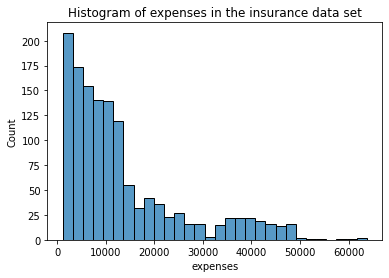

```python
# Data exploration: some examples
# Histogram of insurance expenses
snsplot = sns.histplot(x='expenses', data = insurance)
snsplot.set_title("Histogram of expenses in the insurance data set")
```

```python
# exploring relationships among all numeric variables: correlation matrix
insurance.corr()
```

|  | age | bmi | children | expenses |
| --- | --- | --- | --- | --- |
| age | 1.000000 | 0.109341 | 0.042469 | 0.299008 |
| bmi | 0.109341 | 1.000000 | 0.012645 | 0.198576 |
| children | 0.042469 | 0.012645 | 1.000000 | 0.067998 |
| expenses | 0.299008 | 0.198576 | 0.067998 | 1.000000 |

### Partition the data set

```python
# Create dummy variables
insurance = pd.get_dummies(insurance, columns=['sex','smoker','region'], drop_first=True)
insurance
```

|  | age | bmi | children | expenses | sex_male | smoker_yes | region_northwest | region_southeast | region_southwest |
| --- | --- | --- | --- | --- | --- | --- | --- | --- | --- |
| 0 | 19 | 27.9 | 0 | 16884.92 | 0 | 1 | 0 | 0 | 1 |
| 1 | 18 | 33.8 | 1 | 1725.55 | 1 | 0 | 0 | 1 | 0 |
| 2 | 28 | 33.0 | 3 | 4449.46 | 1 | 0 | 0 | 1 | 0 |
| 3 | 33 | 22.7 | 0 | 21984.47 | 1 | 0 | 1 | 0 | 0 |
| 4 | 32 | 28.9 | 0 | 3866.86 | 1 | 0 | 1 | 0 | 0 |
| ... | ... | ... | ... | ... | ... | ... | ... | ... | ... |
| 1333 | 50 | 31.0 | 3 | 10600.55 | 1 | 0 | 1 | 0 | 0 |
| 1334 | 18 | 31.9 | 0 | 2205.98 | 0 | 0 | 0 | 0 | 0 |
| 1335 | 18 | 36.9 | 0 | 1629.83 | 0 | 0 | 0 | 1 | 0 |
| 1336 | 21 | 25.8 | 0 | 2007.95 | 0 | 0 | 0 | 0 | 1 |
| 1337 | 61 | 29.1 | 0 | 29141.36 | 0 | 1 | 1 | 0 | 0 |

1338 rows × 9 columns

```python
# Partition the data
target = insurance['expenses']
predictors = insurance.drop(['expenses'],axis=1)
predictors_train_insurance, predictors_test_insurance, target_train_insurance, target_test_insurance = train_test_split(predictors, target, test_size=0.3, random_state=0)
print(predictors_train_insurance.shape, predictors_test_insurance.shape, target_train_insurance.shape, target_test_insurance.shape)
```

```
(936, 8) (402, 8) (936,) (402,)
```

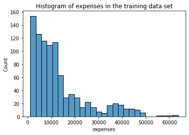

```python
# Examine the distribution of target variable for training data set
snsplot = sns.histplot(data = target_train_insurance)
snsplot.set_title("Histogram of expenses in the training data set")
```

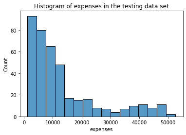

```python
# Examine the distribution of target variable for testing data set
snsplot = sns.histplot(data = target_test_insurance)
snsplot.set_title("Histogram of expenses in the testing data set")
```

### SVM model

```python
# Build a SVM model with default setting (C = 1.0)
model_SVM1 = SVR()
model_SVM1.fit(predictors_train_insurance, target_train_insurance)
```

```
SVR()
```

```python
# Make predictions on testing data
predictions_on_test_insurance = model_SVM1.predict(predictors_test_insurance)
```

```python
# Examine the evaluation results on testing data: MAE and RMSE
MAE = mean_absolute_error(target_test_insurance, predictions_on_test_insurance)
RMSE = mean_squared_error(target_test_insurance, predictions_on_test_insurance, squared=False)
print("MAE:", MAE)
print("RMSE:", RMSE)
```

```
MAE: 8674.695576543052
RMSE: 13175.419298851317
```

```python
# Build a SVM model with C = 10.0
model_SVM2 = SVR(C=10)
model_SVM2.fit(predictors_train_insurance, target_train_insurance)
```

```
SVR(C=10)
```

```python
# Make predictions on testing data
predictions_on_test_insurance = model_SVM2.predict(predictors_test_insurance)
```

```python
# Examine the evaluation results on testing data: MAE and RMSE
MAE = mean_absolute_error(target_test_insurance, predictions_on_test_insurance)
RMSE = mean_squared_error(target_test_insurance, predictions_on_test_insurance, squared=False)
print("MAE:", MAE)
print("RMSE:", RMSE)
```

```
MAE: 8351.694901193036
RMSE: 13139.615173118493
```

```python
# Build a SVM model with C = 100.0
model_SVM3 = SVR(C=100)
model_SVM3.fit(predictors_train_insurance, target_train_insurance)
```

```
SVR(C=100)
```

```python
# Make predictions on testing data
predictions_on_test_insurance = model_SVM3.predict(predictors_test_insurance)
```

```python
# Examine the evaluation results on testing data: MAE and RMSE
MAE = mean_absolute_error(target_test_insurance, predictions_on_test_insurance)
RMSE = mean_squared_error(target_test_insurance, predictions_on_test_insurance, squared=False)
print("MAE:", MAE)
print("RMSE:", RMSE)
```

```
MAE: 6999.272056756078
RMSE: 13386.317466855004
```

Q1. Which C value provides the best performance?  
C=100

Q3. Assume that you will lose each dollar your model’s prediction misses due to an over-estimation or under-estimation. Which evaluation metric you should use?  
MAE

//model_SVM3 (lowest MAE)

Q4. Assume that the penalty for an erroneous prediction increases with the difference between the actual and predicted values. Which evaluation metric you should use?  
RMSE

//model_SVM2 (lowest RMSE)

### MLP model

```python
from scipy.sparse.construct import random
#Build MLP model contains two hidden layers: 16 hidden nodes for the first layer, and 8 hidden nodes for the second layer. Set random_state=1.
model_MLP1 = MLPRegressor(random_state=1, hidden_layer_sizes=(16,8))
model_MLP1.fit(predictors_train_insurance, target_train_insurance)
```

```
MLPRegressor(hidden_layer_sizes=(16, 8), random_state=1)
```

```python
# Make predictions on testing data
predictions_on_test_insurance = model_MLP1.predict(predictors_test_insurance)
```

```python
# Examine the evaluation results on testing data: MAE and RMSE
MAE = mean_absolute_error(target_test_insurance, predictions_on_test_insurance)
RMSE = mean_squared_error(target_test_insurance, predictions_on_test_insurance, squared=False)
print("MAE:", MAE)
print("RMSE:", RMSE)
```

```
MAE: 8839.039197684291
RMSE: 11807.625278012829
```

```python
# Build MLP model contains three hidden layers: 8 hidden nodes for the first layer, 4 hidden nodes for the second layer, and 4 hidden nodes for the third layer. Set random_state=1.
model_MLP2 = MLPRegressor(random_state=1, hidden_layer_sizes=(8,4,4))
model_MLP2.fit(predictors_train_insurance, target_train_insurance)
```

```
MLPRegressor(hidden_layer_sizes=(8, 4, 4), random_state=1)
```

```python
# Make predictions on testing data
predictions_on_test_insurance = model_MLP2.predict(predictors_test_insurance)
```

```python
# Examine the evaluation results on testing data: MAE and RMSE
MAE = mean_absolute_error(target_test_insurance, predictions_on_test_insurance)
RMSE = mean_squared_error(target_test_insurance, predictions_on_test_insurance, squared=False)
print("MAE:", MAE)
print("RMSE:", RMSE)
```

```
MAE: 8427.704633364938
RMSE: 11993.153909886738
```

## Part 2. SVM and Neural Network for classification

This data set contains information of cars purchased at the Auction.  
We will use this file to predict the quality of buying decisions and visualize decision processes.  
VARIABLE DESCRIPTIONS:  
Auction: Auction provider at which the vehicle was purchased  
Color: Vehicle Color  
IsBadBuy: Identifies if the kicked vehicle was an avoidable purchase  
MMRCurrentAuctionAveragePrice: Acquisition price for this vehicle in average condition as of current day  
Size: The size category of the vehicle (Compact, SUV, etc.)  
TopThreeAmericanName:Identifies if the manufacturer is one of the top three American manufacturers  
VehBCost: Acquisition cost paid for the vehicle at time of purchase  
VehicleAge: The Years elapsed since the manufacturer's year  
VehOdo: The vehicles odometer reading  
WarrantyCost: Warranty price (term=36month and millage=36K)  
WheelType: The vehicle wheel type description (Alloy, Covers)

Target variable: **IsBadBuy**

### Upload and clean data

```python
# Import libraries
import pandas as pd
import seaborn as sns
from sklearn.model_selection import train_test_split
from sklearn.svm import SVC
from sklearn.neural_network import MLPClassifier
from matplotlib import pyplot as plt
from sklearn.metrics import plot_confusion_matrix
from sklearn.metrics import classification_report
```

```python
# Read data
carAuction = pd.read_csv("/content/drive/MyDrive/IS470_data/carAuction.csv")
carAuction
```

|  | Auction | Color | IsBadBuy | MMRCurrentAuctionAveragePrice | Size | TopThreeAmericanName | VehBCost | VehicleAge | VehOdo | WarrantyCost | WheelType |
| --- | --- | --- | --- | --- | --- | --- | --- | --- | --- | --- | --- |
| 0 | ADESA | WHITE | No | 2871 | LARGE TRUCK | FORD | 5300 | 8 | 75419 | 869 | Alloy |
| 1 | ADESA | GOLD | Yes | 1840 | VAN | FORD | 3600 | 8 | 82944 | 2322 | Alloy |
| 2 | ADESA | RED | No | 8931 | SMALL SUV | CHRYSLER | 7500 | 4 | 57338 | 588 | Alloy |
| 3 | ADESA | GOLD | No | 8320 | CROSSOVER | FORD | 8500 | 5 | 55909 | 1169 | Alloy |
| 4 | ADESA | GREY | No | 11520 | LARGE TRUCK | FORD | 10100 | 5 | 86702 | 853 | Alloy |
| ... | ... | ... | ... | ... | ... | ... | ... | ... | ... | ... | ... |
| 9995 | ADESA | RED | No | 7536 | SMALL SUV | CHRYSLER | 6600 | 4 | 85377 | 983 | Alloy |
| 9996 | ADESA | BLACK | No | 4921 | LARGE TRUCK | GM | 7000 | 7 | 89665 | 1543 | Alloy |
| 9997 | ADESA | BLACK | No | 9263 | MEDIUM SUV | CHRYSLER | 9000 | 4 | 59383 | 1417 | Alloy |
| 9998 | ADESA | BLUE | No | 3240 | MEDIUM | OTHER | 5500 | 4 | 48642 | 482 | Covers |
| 9999 | ADESA | SILVER | No | 6148 | MEDIUM SUV | FORD | 7000 | 5 | 82563 | 1243 | Alloy |

10000 rows × 11 columns

```python
# Show the head rows of a data frame
carAuction.head()
```

|  | Auction | Color | IsBadBuy | MMRCurrentAuctionAveragePrice | Size | TopThreeAmericanName | VehBCost | VehicleAge | VehOdo | WarrantyCost | WheelType |
| --- | --- | --- | --- | --- | --- | --- | --- | --- | --- | --- | --- |
| 0 | ADESA | WHITE | No | 2871 | LARGE TRUCK | FORD | 5300 | 8 | 75419 | 869 | Alloy |
| 1 | ADESA | GOLD | Yes | 1840 | VAN | FORD | 3600 | 8 | 82944 | 2322 | Alloy |
| 2 | ADESA | RED | No | 8931 | SMALL SUV | CHRYSLER | 7500 | 4 | 57338 | 588 | Alloy |
| 3 | ADESA | GOLD | No | 8320 | CROSSOVER | FORD | 8500 | 5 | 55909 | 1169 | Alloy |
| 4 | ADESA | GREY | No | 11520 | LARGE TRUCK | FORD | 10100 | 5 | 86702 | 853 | Alloy |

```python
# Examine variable type
carAuction.dtypes
```

```
Auction                          object
Color                            object
IsBadBuy                         object
MMRCurrentAuctionAveragePrice     int64
Size                             object
TopThreeAmericanName             object
VehBCost                          int64
VehicleAge                        int64
VehOdo                            int64
WarrantyCost                      int64
WheelType                        object
dtype: object
```

```python
# Change categorical variables to "category"
carAuction['Auction'] = carAuction['Auction'].astype('category')
carAuction['Color'] = carAuction['Color'].astype('category')
carAuction['IsBadBuy'] = carAuction['IsBadBuy'].astype('category')
carAuction['Size'] = carAuction['Size'].astype('category')
carAuction['TopThreeAmericanName'] = carAuction['TopThreeAmericanName'].astype('category')
carAuction['WheelType'] = carAuction['WheelType'].astype('category')
```

```python
# Examine variable type
carAuction.dtypes
```

```
Auction                          category
Color                            category
IsBadBuy                         category
MMRCurrentAuctionAveragePrice       int64
Size                             category
TopThreeAmericanName             category
VehBCost                            int64
VehicleAge                          int64
VehOdo                              int64
WarrantyCost                        int64
WheelType                        category
dtype: object
```

### 2. Partition the data set

```python
# Create dummy variables
carAuction = pd.get_dummies(carAuction, columns=['Auction','Color','Size','TopThreeAmericanName','WheelType'], drop_first=True)
carAuction
```

|  | IsBadBuy | MMRCurrentAuctionAveragePrice | VehBCost | VehicleAge | VehOdo | WarrantyCost | Auction_MANHEIM | Auction_OTHER | Color_BLACK | Color_BLUE | ... | Size_SMALL TRUCK | Size_SPECIALTY | Size_SPORTS | Size_VAN | TopThreeAmericanName_FORD | TopThreeAmericanName_GM | TopThreeAmericanName_OTHER | WheelType_Covers | WheelType_Special | WheelType_unkwnWheel |
| --- | --- | --- | --- | --- | --- | --- | --- | --- | --- | --- | --- | --- | --- | --- | --- | --- | --- | --- | --- | --- | --- |
| 0 | No | 2871 | 5300 | 8 | 75419 | 869 | 0 | 0 | 0 | 0 | ... | 0 | 0 | 0 | 0 | 1 | 0 | 0 | 0 | 0 | 0 |
| 1 | Yes | 1840 | 3600 | 8 | 82944 | 2322 | 0 | 0 | 0 | 0 | ... | 0 | 0 | 0 | 1 | 1 | 0 | 0 | 0 | 0 | 0 |
| 2 | No | 8931 | 7500 | 4 | 57338 | 588 | 0 | 0 | 0 | 0 | ... | 0 | 0 | 0 | 0 | 0 | 0 | 0 | 0 | 0 | 0 |
| 3 | No | 8320 | 8500 | 5 | 55909 | 1169 | 0 | 0 | 0 | 0 | ... | 0 | 0 | 0 | 0 | 1 | 0 | 0 | 0 | 0 | 0 |
| 4 | No | 11520 | 10100 | 5 | 86702 | 853 | 0 | 0 | 0 | 0 | ... | 0 | 0 | 0 | 0 | 1 | 0 | 0 | 0 | 0 | 0 |
| ... | ... | ... | ... | ... | ... | ... | ... | ... | ... | ... | ... | ... | ... | ... | ... | ... | ... | ... | ... | ... | ... |
| 9995 | No | 7536 | 6600 | 4 | 85377 | 983 | 0 | 0 | 0 | 0 | ... | 0 | 0 | 0 | 0 | 0 | 0 | 0 | 0 | 0 | 0 |
| 9996 | No | 4921 | 7000 | 7 | 89665 | 1543 | 0 | 0 | 1 | 0 | ... | 0 | 0 | 0 | 0 | 0 | 1 | 0 | 0 | 0 | 0 |
| 9997 | No | 9263 | 9000 | 4 | 59383 | 1417 | 0 | 0 | 1 | 0 | ... | 0 | 0 | 0 | 0 | 0 | 0 | 0 | 0 | 0 | 0 |
| 9998 | No | 3240 | 5500 | 4 | 48642 | 482 | 0 | 0 | 0 | 1 | ... | 0 | 0 | 0 | 0 | 0 | 0 | 1 | 1 | 0 | 0 |
| 9999 | No | 6148 | 7000 | 5 | 82563 | 1243 | 0 | 0 | 0 | 0 | ... | 0 | 0 | 0 | 0 | 1 | 0 | 0 | 0 | 0 | 0 |

10000 rows × 40 columns

```python
# Partition the data
target = carAuction['IsBadBuy']
predictors = carAuction.drop(['IsBadBuy'],axis=1)
predictors_train_car, predictors_test_car, target_train_car, target_test_car = train_test_split(predictors, target, test_size=0.3, random_state=0)
print(predictors_train_car.shape, predictors_test_car.shape, target_train_car.shape, target_test_car.shape)
```

```
(7000, 39) (3000, 39) (7000,) (3000,)
```

```python
# Examine the porportion of target variable for training data set
print(target_train_car.value_counts(normalize=True))
```

```
No     0.869571
Yes    0.130429
Name: IsBadBuy, dtype: float64
```

```python
# Examine the porportion of target variable for testing data set
print(target_test_car.value_counts(normalize=True))
```

```
No     0.872667
Yes    0.127333
Name: IsBadBuy, dtype: float64
```

### SVM model

```python
# Build a SVM model with default setting (C = 1.0)
model_SVM4 = SVC()
model_SVM4.fit(predictors_train_car, target_train_car)
```

```
SVC()
```

```python
# Make predictions on testing data
predictions_on_test_car = model_SVM4.predict(predictors_test_car)
```

```
<sklearn.metrics._plot.confusion_matrix.ConfusionMatrixDisplay at 0x7f007472a450>
```

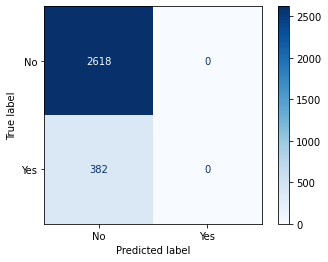

```python
# Examine the evaluation results on testing data: confusion_matrix
plot_confusion_matrix(model_SVM4, predictors_test_car, target_test_car, cmap=plt.cm.Blues, values_format='d')
```

```python
# Examine the evaluation results on testing data: accuracy, precision, recall, and f1-score
print(classification_report(target_test_car, predictions_on_test_car))
```

```
              precision    recall  f1-score   support

          No       0.87      1.00      0.93      2618
         Yes       0.00      0.00      0.00       382

    accuracy                           0.87      3000
   macro avg       0.44      0.50      0.47      3000
weighted avg       0.76      0.87      0.81      3000
```

### MLP model

```python
#Build MLP model contains two hidden layers: 16 hidden nodes for the first layer, and 10 hidden nodes for the second layer. Set random_state=1.
model_MLP3 = MLPClassifier(random_state=1, hidden_layer_sizes=(16,10))
model_MLP3.fit(predictors_train_car, target_train_car)
```

```
MLPClassifier(hidden_layer_sizes=(16, 10), random_state=1)
```

```python
# Make predictions on testing data
predictions_on_test_car = model_MLP3.predict(predictors_test_car)
```

```
<sklearn.metrics._plot.confusion_matrix.ConfusionMatrixDisplay at 0x7f007463ec90>
```

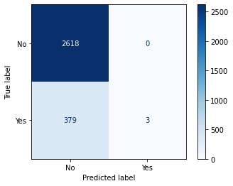

```python
# Examine the evaluation results on testing data: confusion_matrix
plot_confusion_matrix(model_MLP3, predictors_test_car, target_test_car, cmap=plt.cm.Blues, values_format='d')
```

```python
# Examine the evaluation results on testing data: accuracy, precision, recall, and f1-score
print(classification_report(target_test_car, predictions_on_test_car))
```

```
              precision    recall  f1-score   support

          No       0.87      1.00      0.93      2618
         Yes       1.00      0.01      0.02       382

    accuracy                           0.87      3000
   macro avg       0.94      0.50      0.47      3000
weighted avg       0.89      0.87      0.82      3000
```

Q5. Which model has better performance on carAuction data, SVM or neural network? why?  
The neural network because the model performs slightly better on the 'Yes' class while having the same performance on the 'No' class and same overall performance.

```python
!jupyter nbconvert --to html "/content/drive/MyDrive/IS470_lab/IS470_lab7.ipynb"
```